# 单变量绘图

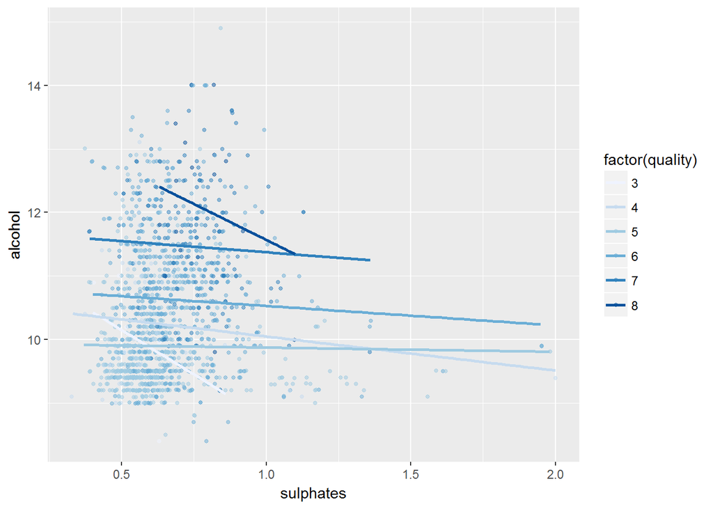

#### 硫酸盐对评分影响不大，酒精影响较大。

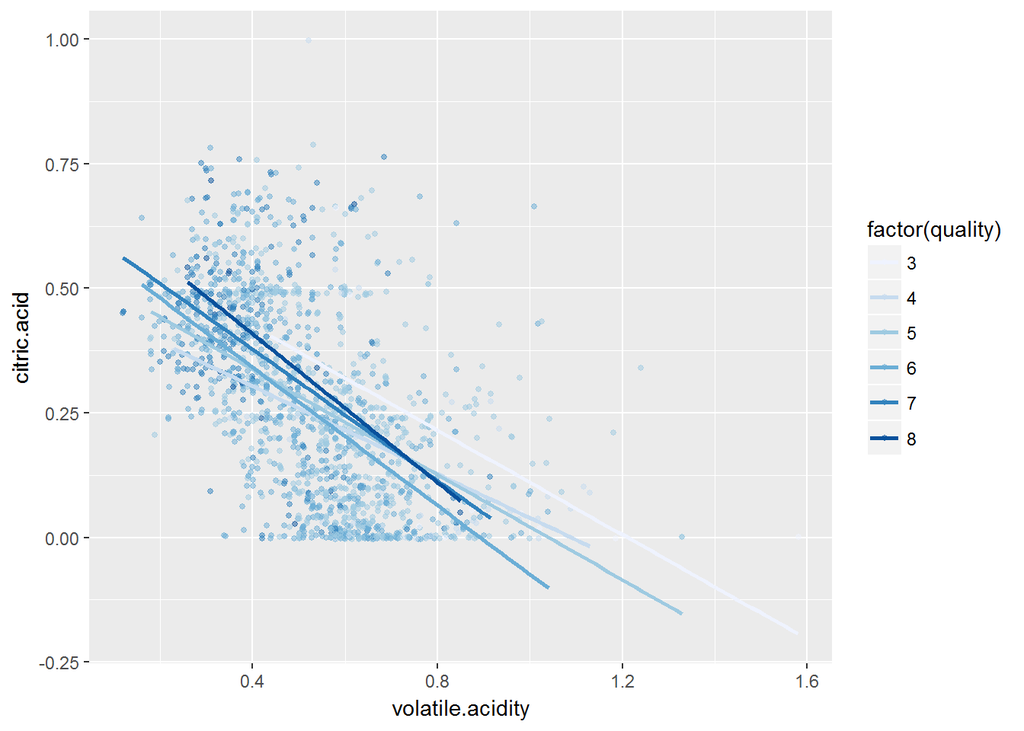

#### 相关度较高，挥发性酸跟柠檬酸呈反比。

```
##
## Calls:
## m1: lm(formula = quality ~ alcohol, data = wine)
## m2: lm(formula = quality ~ alcohol + sulphates, data = wine)
## m3: lm(formula = quality ~ alcohol + sulphates + citric.acid, data = wine)
## m4: lm(formula = quality ~ alcohol + sulphates + citric.acid + volatile.acidity,
##     data = wine)
##
## ================================================================
##                        m1         m2         m3         m4
## ----------------------------------------------------------------
##   (Intercept)        1.875***   1.375***   1.434***   2.646***
##                     (0.175)    (0.177)    (0.176)    (0.201)
##   alcohol            0.361***   0.346***   0.338***   0.309***
##                     (0.017)    (0.016)    (0.016)    (0.016)
##   sulphates                     0.994***   0.814***   0.696***
##                                (0.102)    (0.107)    (0.103)
##   citric.acid                              0.513***  -0.079
##                                           (0.093)    (0.104)
##   volatile.acidity                                   -1.265***
##                                                      (0.113)
## ----------------------------------------------------------------
##   R-squared              0.2        0.3        0.3        0.3
##   adj. R-squared         0.2        0.3        0.3        0.3
##   sigma                  0.7        0.7        0.7        0.7
##   F                    468.3      295.0      210.5      201.8
##   p                      0.0        0.0        0.0        0.0
##   Log-likelihood     -1721.1    -1675.1    -1660.0    -1599.1
##   Deviance             805.9      760.9      746.6      691.9
##   AIC                 3448.1     3358.3     3329.9     3210.2
##   BIC                 3464.2     3379.8     3356.8     3242.4
##   N                   1599       1599       1599       1599
## ================================================================
```

该线性模型只能解释30%的评分方差，并非一个特别合适的模型

# 多变量分析

### **Talk about some of the relationships you observed in this part of the investigation. Were there features that strengthened each other in terms of looking at your feature(s) of interest?**

#### 更低的硫酸盐含量和的酒精度数会集中在挥发性酸数值的0.6-0.8之间，我还不清楚为什么会有这样的现象，可能跟他们的物理性质有关吧；当柠檬酸指数为0时，大多数酒精度数和硫酸盐含量都比较低；低酒精度数相对集中在硫酸盐含量为0.5左右，评分处在中间位置。同事在酒精度数9-10度之间，硫酸盐含量最低。

### **Were there any interesting or surprising interactions between features?**

#### 在挥发性酸数值为0.6-0.8之间集中了更多的低硫酸盐含量和低酒精度数，这让我感到很吃惊，我不清楚在这个范围的挥发性酸是否存在有什么特质，造成这种现象。这又需要日后进一步的探索。

### **OPTIONAL: Did you create any models with your dataset? Discuss the strengths and limitations of your model.**

#### 用评分和酒精浓度建立了一个线性模型，但似乎表现并不是很好，只能解释评分方差的20%。在加入了硫酸盐之后，稍微好了点，但也只能解释30%，随后又加入了柠檬酸和挥发性酸但是并没有造成影响

# 最终绘图汇总

### 绘图一

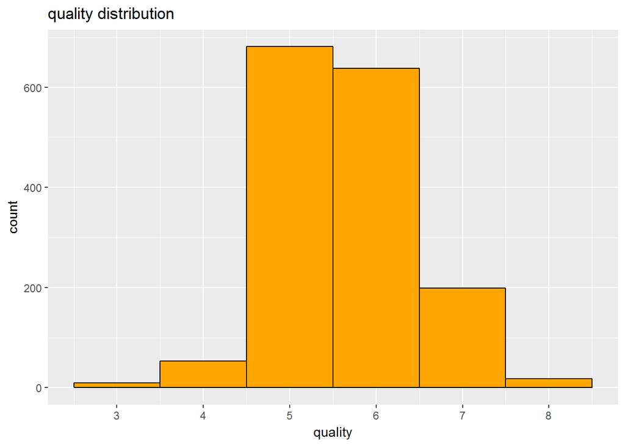

### 描述一

#### 评分呈正态分布，符合个人预期。其中评分在5分的红酒数量最多。

### 绘图二

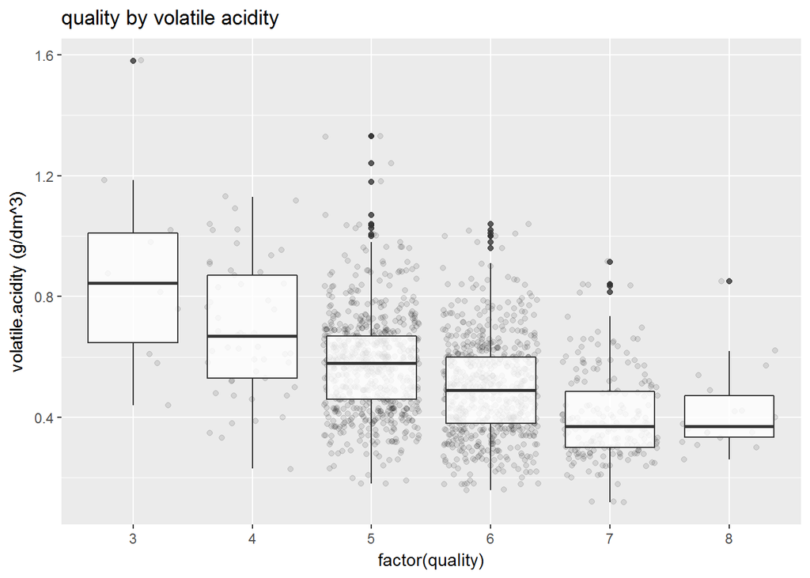

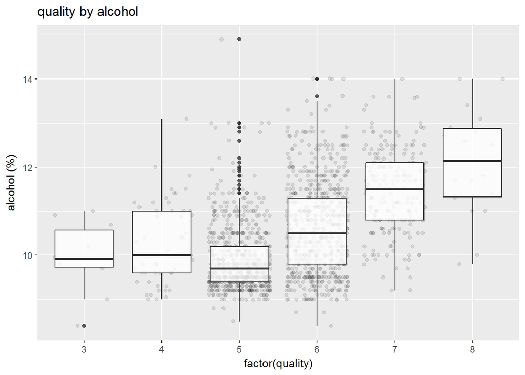

### 描述二

#### 随着挥发性酸含量的增加评分下降，这与我的预期相符，因为挥发性酸含量过高会有导致一股难闻的醋味。另外我发现酒精度数也与评分呈现出一定的相关性，度数越高评分也越高，这看起来好像人们都更喜欢喝度数高的酒。

### 绘图三

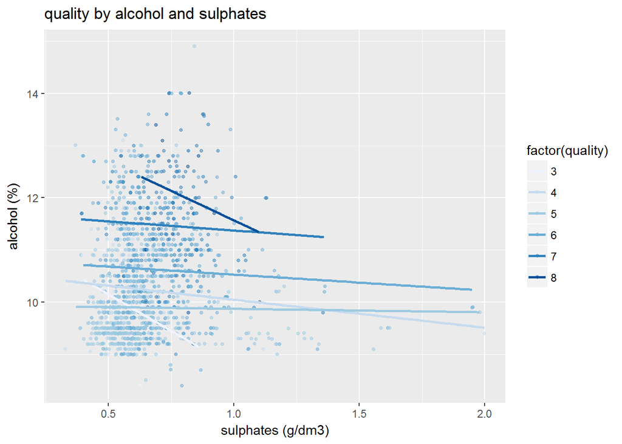

### 描述三

#### 用该图展现的关系构造了线性模型，但是拟合程度不理想。该图展示了，在一定范围内保持硫酸盐浓度不变，酒精度数越高评分越高。

# 反思

#### 该数据集包含了1599条红酒记录，以及11个变量（10个客观变量，1个主观变量）。我通过对这个数据集进行探索，希望了解红酒的评分是与那些因素相关，在最后我尝试建立了一个预测红酒评分的线性模型，但是效果并不是很好，还需要在后续探索中改进。

#### 在开始探索前，我预计固定性酸、挥发性酸、柠檬酸、残糖和硫酸盐会对评分起到较大的影响。在探索后我发现，挥发性酸、柠檬酸、硫酸盐和酒精度数是对于评分起到较大影响的几个因素，另外让我感到吃惊的是残糖这个因素实际上并没有对评分造成太大影响，这与我开始的假设并不相符，因为基于日常经验，糖份应该是对红酒影响非常大的一个因素才对。

#### 在最后我建立了一个预测评分的模型，但是这个模型效果不好。个人猜测可能是在建立模型时需要对变量进行一些转化，但我尝试了log转化，平方转化等，效果都不佳，在建模这一块，暂时没有特别好的成果，留待日后探索中在日趋完善吧。